# Practical Machine Learning Project

Julio Matarrita

## Background

Using devices such as Jawbone Up, Nike FuelBand, and Fitbit it is now possible to collect a large amount of data about personal activity relatively inexpensively. These type of devices are part of the quantified self movement – a group of enthusiasts who take measurements about themselves regularly to improve their health, to find patterns in their behavior, or because they are tech geeks. One thing that people regularly do is quantify how much of a particular activity they do, but they rarely quantify how well they do it. In this project, your goal will be to use data from accelerometers on the belt, forearm, arm, and dumbell of 6 participants. They were asked to perform barbell lifts correctly and incorrectly in 5 different ways. More information is available from the website here: http://groupware.les.inf.puc-rio.br/har (see the section on the Weight Lifting Exercise Dataset).

## Data

The training data for this project are available here: https://d396qusza40orc.cloudfront.net/predmachlearn/pml-training.csv

The test data are available here: https://d396qusza40orc.cloudfront.net/predmachlearn/pml-testing.csv

The data for this project come from this source: http://groupware.les.inf.puc-rio.br/har. If you use the document you create for this class for any purpose please cite them as they have been very generous in allowing their data to be used for this kind of assignment.

## Project Objective

The goal of your project is to predict the manner in which they did the exercise. This is the “classe” variable in the training set. You may use any of the other variables to predict with. You should create a report describing how you built your model, how you used cross validation, what you think the expected out of sample error is, and why you made the choices you did. You will also use your prediction model to predict 20 different test cases.

## Reproducibility

In order to reproduce the same results, you need a certain set of packages, as well as setting a pseudo random seed equal to the one I used.

To install differente package in R, run this command (change packgae name by the package that you need instal): install.packages(“packagename”)

The librarys that are necesary for this project are: caret, rpart, rpart.plot, RColorBrewer, rattle, and randomForest.

Previously select the working directory with setwd() comand.

```r
setwd("C:\\Users\\X201\\Dropbox\\MachineLearning")
library(caret)
library(rpart)
library(rpart.plot)
library(RColorBrewer)
library(rattle)
library(randomForest)
```

Finally, load the same seed with the following line of code:

```r
set.seed(12000)
```

## Read the data

To get the training date use the following line of code:

```r
trainingUrl <- "https://d396qusza40orc.cloudfront.net/predmachlearn/pml-training.csv"
training <- read.csv(url(trainingUrl), na.strings=c("NA","#DIV/0!",""))
```

To get the test date use the following line of code:

```r
testingUrl <- "https://d396qusza40orc.cloudfront.net/predmachlearn/pml-testing.csv"
testing <- read.csv(url(testingUrl), na.strings=c("NA","#DIV/0!",""))
```

For validate the models is necessary create a training and testing data of the training data set.

For this use the following line of code:

```r
inTrain <- createDataPartition(y=training$classe, p=0.6, list=FALSE)
myTraining <- training[inTrain, ]
myTesting <- training[-inTrain, ]
dim(myTraining)
```

```
## [1] 11776   160
```

```r
dim(myTesting)
```

```
## [1] 7846  160
```

## Cleaning Data

The following transformations are use to clean the data.

1. Cleaning NearZeroVariance Variables Run this code to view possible NZV Variables:

```r
myDataNZV <- nearZeroVar(myTraining, saveMetrics=TRUE)
myTraining <- myTraining[,myDataNZV$nzv==FALSE]
```

2. Remove first colum of myTraining

```r
myTraining <- myTraining[c(-1)]
```

3. Remove the variables with more of 60% of NA

```r
trainingRemove <- myTraining
for(i in 1:length(myTraining)) {
    if( sum( is.na( myTraining[, i] ) ) /nrow(myTraining) >= .6) {
        for(j in 1:length(trainingRemove)) {
            if( length( grep(names(myTraining[i]), names(trainingRemove)[j]) ) == 1)  {
                trainingRemove <- trainingRemove[ , -j]
            }
        }
    }
}

myTraining <- trainingRemove
rm(trainingRemove)
```

4. Now let us do the exact same 3 transformations but for our myTesting and testing data sets.

```r
clean1 <- colnames(myTraining)
clean2 <- colnames(myTraining[, -58])
myTesting <- myTesting[clean1]
testing <- testing[clean2]
```

5. In order to ensure proper functioning of Decision Trees and RandomForest algorithm with the testing data set (data set provided), we need to coerce the data into the same type.

```r
for (i in 1:length(testing) ) {
        for(j in 1:length(myTraining)) {
        if( length( grep(names(myTraining[i]), names(testing)[j]) ) ==1)  {
            class(testing[j]) <- class(myTraining[i])
        }
    }
}

testing <- rbind(myTraining[2, -58] , testing)
testing <- testing[-1,]
```

## Prediction with Decision Trees

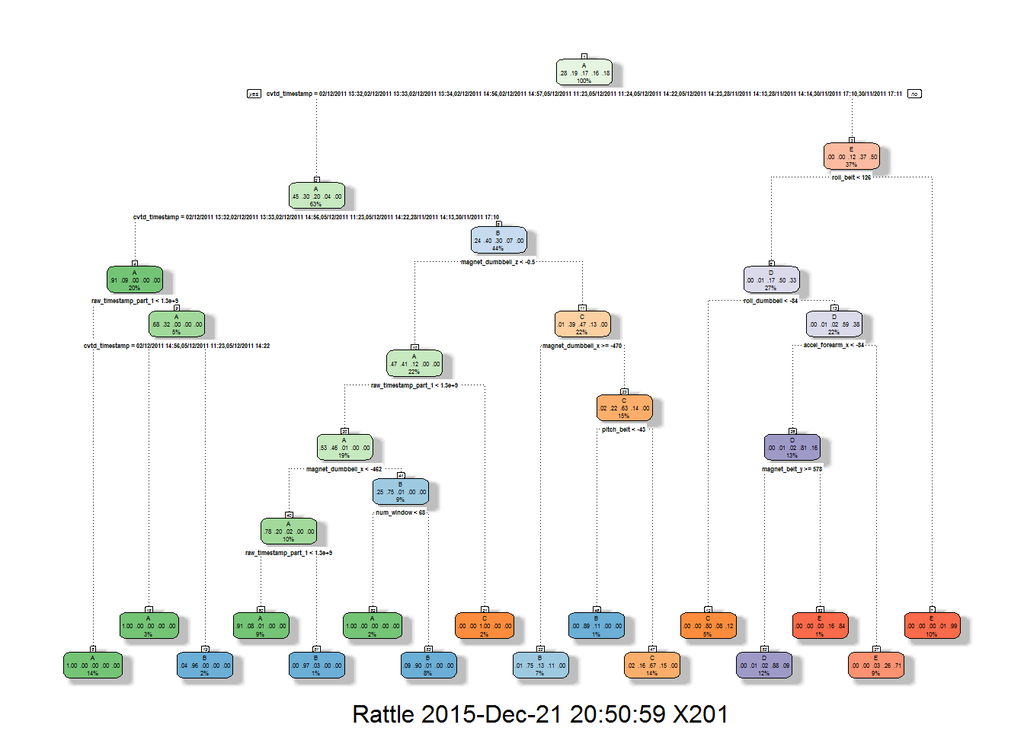

```r
modFit1 <- rpart(classe ~ ., data=myTraining, method="class")
fancyRpartPlot(modFit1)
```

Predictions and confusion matrix of model decision tree:

```r
predictions1 <- predict(modFit1, myTesting, type = "class")
confDecTree <- confusionMatrix(predictions1, myTesting$classe)
confDecTree
```

```
## Confusion Matrix and Statistics
##
##           Reference
## Prediction    A    B    C    D    E
##          A 2138   65    6    3    0
##          B   76 1278   89   66    0
##          C   18  166 1225  184   49
##          D    0    9   31  826   79
##          E    0    0   17  207 1314
##
## Overall Statistics
##
##                Accuracy : 0.8643
##                  95% CI : (0.8565, 0.8718)
##     No Information Rate : 0.2845
##     P-Value [Acc > NIR] : < 2.2e-16
##
##                   Kappa : 0.8283
##  Mcnemar's Test P-Value : NA
##
## Statistics by Class:
##
##                      Class: A Class: B Class: C Class: D Class: E
## Sensitivity            0.9579   0.8419   0.8955   0.6423   0.9112
## Specificity            0.9868   0.9635   0.9356   0.9819   0.9650
## Pos Pred Value         0.9665   0.8469   0.7460   0.8741   0.8544
## Neg Pred Value         0.9833   0.9621   0.9770   0.9333   0.9797
## Prevalence             0.2845   0.1935   0.1744   0.1639   0.1838
## Detection Rate         0.2725   0.1629   0.1561   0.1053   0.1675
## Detection Prevalence   0.2819   0.1923   0.2093   0.1204   0.1960
## Balanced Accuracy      0.9724   0.9027   0.9155   0.8121   0.9381
```

## Prediction with Random Forests

```r
modFit2 <- randomForest(classe ~ ., data=myTraining)
```

```r
predictions2 <- predict(modFit2, myTesting, type = "class")
confRF <- confusionMatrix(predictions2, myTesting$classe)
confRF
```

```
## Confusion Matrix and Statistics
##
##           Reference
## Prediction    A    B    C    D    E
##          A 2232    1    0    0    0
##          B    0 1517    2    0    0
##          C    0    0 1359    1    0
##          D    0    0    7 1282    2
##          E    0    0    0    3 1440
##
## Overall Statistics
##
##                Accuracy : 0.998
##                  95% CI : (0.9967, 0.9988)
##     No Information Rate : 0.2845
##     P-Value [Acc > NIR] : < 2.2e-16
##
##                   Kappa : 0.9974
##  Mcnemar's Test P-Value : NA
##
## Statistics by Class:
##
##                      Class: A Class: B Class: C Class: D Class: E
## Sensitivity            1.0000   0.9993   0.9934   0.9969   0.9986
## Specificity            0.9998   0.9997   0.9998   0.9986   0.9995
## Pos Pred Value         0.9996   0.9987   0.9993   0.9930   0.9979
## Neg Pred Value         1.0000   0.9998   0.9986   0.9994   0.9997
## Prevalence             0.2845   0.1935   0.1744   0.1639   0.1838
## Detection Rate         0.2845   0.1933   0.1732   0.1634   0.1835
## Detection Prevalence   0.2846   0.1936   0.1733   0.1645   0.1839
## Balanced Accuracy      0.9999   0.9995   0.9966   0.9978   0.9991
```

Random Forest has the best result.

## Generating Files to submit answers

Made the prediction in the testing data set using random forest model.

```r
predictions3 <- predict(modFit2, testing, type = "class")
```

Function to generate files with predictions to submit for assignment

```r
pml_write_files = function(x){
  n = length(x)
  for(i in 1:n){
    filename = paste0("problem_id_",i,".txt")
    write.table(x[i],file=filename,quote=FALSE,row.names=FALSE,col.names=FALSE)
  }
}

pml_write_files(predictions3)
```